# Classification of human activity using Machine Learning

## Introduction

Using devices such as Jawbone Up, Nike FuelBand, and Fitbit it is now possible to collect a large amount of data about personal activity relatively inexpensively. These type of devices are part of the quantified self movement - a group of enthusiasts who take measurements about themselves regularly to improve their health, to find patterns in their behavior, or because they are tech geeks. One thing that people regularly do is quantify how much of a particular activity they do, but they rarely quantify how well they do it. In this project, your goal will be to use data from accelerometers on the belt, forearm, arm, and dumbell of 6 participants. They were asked to perform barbell lifts correctly and incorrectly in 5 different ways. More information is available from the website here: http://web.archive.org/web/20161224072740/http:/groupware.les.inf.puc-rio.br/har (see the section on the Weight Lifting Exercise Dataset).

## Data

The training data for this project are available here:

https://d396qusza40orc.cloudfront.net/predmachlearn/pml-training.csv

The test data are available here:

https://d396qusza40orc.cloudfront.net/predmachlearn/pml-testing.csv

## Loading required packages

```r
library(caret)
```

```r
library(rpart)
library(ggplot2)
library(corrplot)
library(randomForest)
library(rattle)
set.seed(2600)
```

## Loading training and test data

```r
#removing X variable from the dataset (first column)
x_training_data <- read.csv("pml-training.csv")[, -1]
dim(x_training_data)
```

```
## [1] 19622   159
```

```r
x_test_data <- read.csv("pml-testing.csv")[, -1]
dim(x_test_data)
```

```
## [1]  20 159
```

## Preprocessing

```r
#removing features with many missing or NA values
NZV <- nearZeroVar(x_training_data)
final_training_data <- x_training_data[, -NZV]
final_test_data <- x_test_data[, -NZV]

NaVals <- sapply(final_training_data, function(x) mean(is.na(x))) > 0.9
final_training_data <- final_training_data[, NaVals == "FALSE"]
final_test_data <- final_test_data[, NaVals == "FALSE"]
```

Removing unnecessary columns that does not contribute to prediction such as raw_timestamp_part_1, raw_timestamp_part_2, cvtd_timestamp, num_window and username.

```r
final_training_data <- final_training_data[, -c(1:5)]
final_test_data <- final_test_data [, -c(1:5)]
head(final_training_data)
```

```
##   roll_belt pitch_belt yaw_belt total_accel_belt gyros_belt_x gyros_belt_y
## 1      1.41       8.07    -94.4                3         0.00         0.00
## 2      1.41       8.07    -94.4                3         0.02         0.00
## 3      1.42       8.07    -94.4                3         0.00         0.00
## 4      1.48       8.05    -94.4                3         0.02         0.00
## 5      1.48       8.07    -94.4                3         0.02         0.02
## 6      1.45       8.06    -94.4                3         0.02         0.00
##   gyros_belt_z accel_belt_x accel_belt_y accel_belt_z magnet_belt_x
## 1        -0.02          -21            4           22            -3
## 2        -0.02          -22            4           22            -7
## 3        -0.02          -20            5           23            -2
## 4        -0.03          -22            3           21            -6
## 5        -0.02          -21            2           24            -6
## 6        -0.02          -21            4           21             0
##   magnet_belt_y magnet_belt_z roll_arm pitch_arm yaw_arm total_accel_arm
```

[output cut: 69 more lines]

## Partitioning Data for cross validation

```r
#preparing data partition for cross validation
toTrain <- createDataPartition(y = final_training_data$classe, p=0.7, list= FALSE)
training <- final_training_data[toTrain, ]
validation_Set <- final_training_data[-toTrain, ]
```

## Training using decision trees

```r
#training the model with decision trees
model_dtree <- train(classe~., data = training, method = "rpart")
predict_training_tree <- predict(model_dtree, training)
CM <- confusionMatrix(predict_training_tree, training$classe)

predict_CV_tree <- predict(model_dtree, validation_Set)
CM_cv_tree <- confusionMatrix(predict_CV_tree, validation_Set$classe)

print(CM_cv_tree)
```

```
## Confusion Matrix and Statistics
##
##           Reference
## Prediction    A    B    C    D    E
##          A 1530  486  479  415  155
##          B   22  386   33  197  162
##          C  117  267  514  352  286
##          D    0    0    0    0    0
##          E    5    0    0    0  479
##
## Overall Statistics
##
##                Accuracy : 0.4943
##                  95% CI : (0.4815, 0.5072)
##     No Information Rate : 0.2845
##     P-Value [Acc > NIR] : < 2.2e-16
##
##                   Kappa : 0.3389
##
##  Mcnemar's Test P-Value : NA
##
## Statistics by Class:
##
##                      Class: A Class: B Class: C Class: D Class: E
## Sensitivity            0.9140  0.33889  0.50097   0.0000  0.44270
## Specificity            0.6355  0.91277  0.78967   1.0000  0.99896
## Pos Pred Value         0.4992  0.48250  0.33464      NaN  0.98967
## Neg Pred Value         0.9489  0.85192  0.88227   0.8362  0.88835
## Prevalence             0.2845  0.19354  0.17434   0.1638  0.18386
## Detection Rate         0.2600  0.06559  0.08734   0.0000  0.08139
## Detection Prevalence   0.5208  0.13594  0.26100   0.0000  0.08224
## Balanced Accuracy      0.7747  0.62583  0.64532   0.5000  0.72083
```

```r
#we see that decision tree model gives accuracy of about 49%.
```

We observe that using decision trees we get accuracy of about 49%. To improve the accuracy we use Random forests.

## Training using Random forests

```r
#training the model with random forest
training.rf <- randomForest(classe~.,data=training, importance=TRUE)

print(training.rf)
```

```
##
## Call:
##  randomForest(formula = classe ~ ., data = training, importance = TRUE)
##                Type of random forest: classification
##                      Number of trees: 500
## No. of variables tried at each split: 7
##
##         OOB estimate of  error rate: 0.53%
## Confusion matrix:
##      A    B    C    D    E class.error
## A 3902    2    0    1    1 0.001024066
## B    8 2644    6    0    0 0.005267118
## C    0   17 2377    2    0 0.007929883
## D    0    0   24 2226    2 0.011545293
## E    0    0    2    8 2515 0.003960396
```

```r
confusionMatrix(predict(training.rf, newdata = validation_Set[,-ncol(validation_Set)]), validation_Set$classe)
```

```
## Confusion Matrix and Statistics
##
##           Reference
## Prediction    A    B    C    D    E
##          A 1674    3    0    0    0
##          B    0 1135    7    0    0
##          C    0    1 1014    1    1
##          D    0    0    5  962    1
##          E    0    0    0    1 1080
##
## Overall Statistics
##
##                Accuracy : 0.9966
##                  95% CI : (0.9948, 0.9979)
##     No Information Rate : 0.2845
##     P-Value [Acc > NIR] : < 2.2e-16
##
##                   Kappa : 0.9957
##
##  Mcnemar's Test P-Value : NA
##
## Statistics by Class:
##
##                      Class: A Class: B Class: C Class: D Class: E
## Sensitivity            1.0000   0.9965   0.9883   0.9979   0.9982
## Specificity            0.9993   0.9985   0.9994   0.9988   0.9998
## Pos Pred Value         0.9982   0.9939   0.9971   0.9938   0.9991
## Neg Pred Value         1.0000   0.9992   0.9975   0.9996   0.9996
## Prevalence             0.2845   0.1935   0.1743   0.1638   0.1839
## Detection Rate         0.2845   0.1929   0.1723   0.1635   0.1835
## Detection Prevalence   0.2850   0.1941   0.1728   0.1645   0.1837
## Balanced Accuracy      0.9996   0.9975   0.9938   0.9984   0.9990
```

```r
accuracy <-c(as.numeric(predict(training.rf,newdata=validation_Set[,-ncol(validation_Set)])==validation_Set$classe))
accuracy <-sum(accuracy)*100/nrow(validation_Set)
```

We observe that we are getting an accuracy of 99.6%. Hence random forests is the most appropriate model for classification of this data set.

## Prediction

Using the trained model of random forests to predict on test dataset.

```r
#predicting on test_set
predict_test_set <- predict(training.rf, final_test_data)
predict_test_set
```

```
##  1  2  3  4  5  6  7  8  9 10 11 12 13 14 15 16 17 18 19 20
##  B  A  B  A  A  E  D  B  A  A  B  C  B  A  E  E  A  B  B  B
## Levels: A B C D E
```

## Checking the importance of features

We will check which feature helped the most in deducing our prediction.

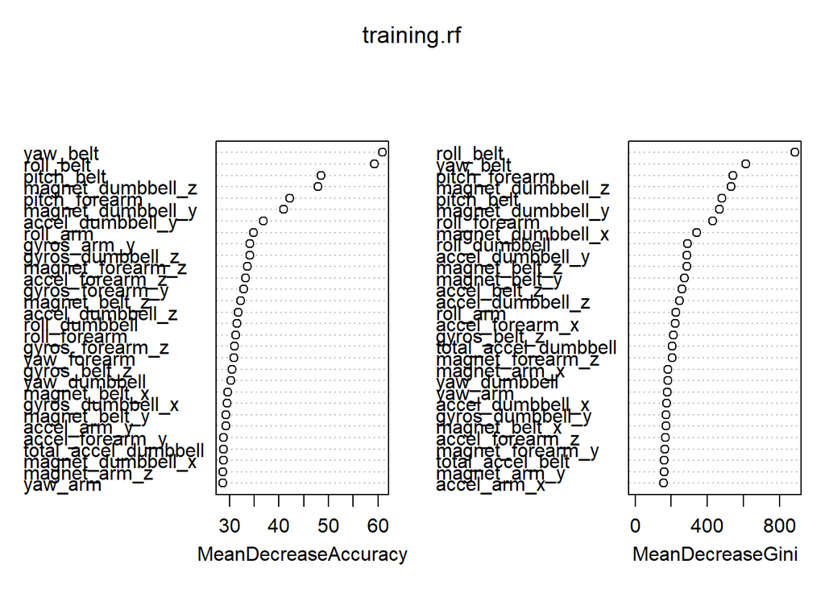

```r
#keeping all important features for prediction
varImpPlot(training.rf, scale = TRUE, sort=TRUE)
```